# SCRIPT Bulk QC and Cleaning

# Goals

1. Process counts tables generated in 200526_bulk_sequence_processing.Rmd and ensure relatively consistent quality across batches, lack of batch effect. Apply batch correction as necessary.
2. Remove problem lanes and samples
3. Determine source of poor alignment and assignent, if any

# Setup

## Load packages

```r
library(tidyverse)
library(DESeq2)
library(googlesheets4)
library(googledrive)
```

```r
library(ggplot2)
library(ggforce)
library(corrplot)
library(viridis)
library(biomaRt)
library(patchwork)
library(gtools)
library(parallel)
cores = 8
mc = getOption("mc.cores", cores)

source("~/utils/R/plotPCA_manual.R")

options(stringsAsFactors = F)

human_mart = useMart("ensembl", "hsapiens_gene_ensembl")
ensembl_conv = getBM(attributes = c("ensembl_gene_id", "external_gene_name"),
                     mart = human_mart)
```

```
## Cache found
```

## Import data

### Metadata

log in to google drive (must be done interactively)

```r
drive_auth(use_oob = T, cache = T) # have to run in console :(
```

```
## Using an auto-discovered, cached token.
## To suppress this message, modify your code or options to clearly consent to the use of a cached token.
## See gargle's "Non-interactive auth" vignette for more details:
## https://gargle.r-lib.org/articles/non-interactive-auth.html
```

```
## The googledrive package is using a cached token for rogangrant2022@u.northwestern.edu.
```

```r
gs4_auth(token = drive_token(), cache = T)
```

```r
rna_metadata = read_sheet("https://docs.google.com/spreadsheets/d/15aq9UMRtTl5E75E5M0mXvbFfxVVuJxrXneKYpo6LzlE/edit#gid=897409272",
                  trim_ws = T,
                  .name_repair = "universal",
                  sheet = "SCRIPT_01 RNAseq Metadata",
                  na = c("", "NA"))
```

```
## Reading from "SCRIPT_01_RNAseq"
```

```
## Range "'SCRIPT_01 RNAseq Metadata'"
```

```
## * `` -> ...17
## * `` -> ...19
## * `Kit lot number` -> Kit.lot.number
## * `Elution vol (ul)` -> Elution.vol..ul.
## * `Date of RNA QC` -> Date.of.RNA.QC
## * ...
```

```r
#clean up colnames
colnames(rna_metadata) = gsub("\\.", "_", colnames(rna_metadata)) #I like underscores
colnames(rna_metadata) = gsub("_+$", "", colnames(rna_metadata)) # remove trailing
colnames(rna_metadata) = gsub("_+", "_", colnames(rna_metadata)) #remove dup underscores
#tube is randomly read in as a list. fix this.
rna_metadata$tubeid_macrophRNA = as.character(rna_metadata$tubeid_macrophRNA)
rna_metadata$tubeid_macrophRNA[rna_metadata$tubeid_macrophRNA == "NULL"] = NA
#take out problem cols (added back)
rna_metadata = rna_metadata %>%
  dplyr::select(-c(RNAseq_batch, Batch_sample))
#remove preceding zeros
rna_metadata = rna_metadata %>%
  mutate_at("tubeid_macrophRNA", function(x){ gsub("^0", "", x) })

#keep track of batches
batch_metadata = read_sheet("https://docs.google.com/spreadsheets/d/15aq9UMRtTl5E75E5M0mXvbFfxVVuJxrXneKYpo6LzlE/edit#gid=897409272",
                  trim_ws = T,
                  .name_repair = "universal",
                  sheet = "SCRIPT_01 RNAseq Library prep layouts",
                  na = c("", "NA"))
```

```
## Reading from "SCRIPT_01_RNAseq"
```

```
## Range "'SCRIPT_01 RNAseq Library prep layouts'"
```

```
## * `Library prep date` -> Library.prep.date
## * `RNA tube ID` -> RNA.tube.ID
## * `Library prep plate` -> Library.prep.plate
## * `Library size (bp)` -> Library.size..bp.
## * `Index i7` -> Index.i7
## * ...
```

```r
batch_metadata = batch_metadata %>%
  dplyr::select(-c(Library.prep.date, Comments)) %>%
  mutate_at(.vars = "RNA.tube.ID", function(x){
    x = gsub("_*R", "", as.character(x), ignore.case = T)}) #repeats are handled better by batch

#merge with rna metadata to account for repeats
rna_metadata = right_join(rna_metadata,
                         batch_metadata,
                         by = c("tubeid_macrophRNA" = "RNA.tube.ID", "tc_pt_study_id" = "Sample")) %>%
  filter(!is.na(RNAseq_batch))

#clean up colnames
colnames(batch_metadata) = gsub("\\.", "_", colnames(batch_metadata)) #I like underscores
colnames(batch_metadata) = gsub("_+$", "", colnames(batch_metadata)) # remove trailing
colnames(batch_metadata) = gsub("_+", "_", colnames(batch_metadata)) #remove dup underscores
#ignore samples for now
batch_metadata = batch_metadata %>%
  dplyr::select(RNAseq_batch, Sequencing_Run_ID) %>%
  na.omit() %>%
  unique() %>%
  filter(!duplicated(RNAseq_batch)) #this ignores repeats for now. Not really relevant to "batch"
batch_metadata = rbind(batch_metadata, c("SCRIPT_RNAseq_Batch_07", "SCRIPT_BATCH_07")) #account for basespace transfer
batch_metadata = as.data.frame(batch_metadata)
```

### Pipeline QC data

```r
seq_dirs = dir(path = "/projects/b1038/Pulmonary/rgrant/script_bulk",
               pattern = "^(\\d|S).*",
               all.files = F,
               full.names = T,
               recursive = F)
mqc_tables = mclapply(seq_dirs, function(dir){
  if(grepl("200520_NB501488_0357_AHHVH5BGXF_copy_RAG", dir)) #because of testing file structure is different
  {
    mqc_path = paste0(dir, "/GRCh37_comparison/results/MultiQC/multiqc_data/multiqc_general_stats.txt")
  } else
  {
    mqc_path = paste0(dir, "/results/MultiQC/multiqc_data/multiqc_general_stats.txt")
  }

  mqc = read.delim(mqc_path)

  #make sure all samples have unique names (hURNA and repeats)
  run = gsub("_copy_RAG", "", basename(dir))
  batch = batch_metadata[which(batch_metadata$Sequencing_Run_ID == run), "RNAseq_batch"]
  mqc$batch = batch
  return(mqc)
})

mqc_metadata = bind_rows(mqc_tables) %>%
  filter(!is.na(QualiMap_mqc.generalstats.qualimap.reads_aligned)) #weird empty rows
mqc_metadata$Sample = paste0(mqc_metadata$Sample, "_R1_001") #format correctly
colnames(mqc_metadata) = gsub("\\.", "_", colnames(mqc_metadata)) #I like underscores
colnames(mqc_metadata) = gsub("_+$", "", colnames(mqc_metadata)) # remove trailing
colnames(mqc_metadata) = gsub("_+", "_", colnames(mqc_metadata)) #remove dup underscores
mqc_metadata$lane_run = paste(mqc_metadata$Sample, mqc_metadata$batch, sep = "_")
```

## Flow data

```r
flow_data = readRDS("/projects/p30623/Box/rgrant/SCRIPT/2020-06-18_SCRIPT_flow_plus_clinical_metadata_processed.rds") %>%
  dplyr::select(tubeid_macrophRNA, percent_CD4_total:preparation)
```

### Counts tables

```r
name_conversion = read.delim("/projects/b1038/Pulmonary/rgrant/script_bulk/200528_NB501488_0359_AHVYTKBGXF_copy_RAG/results/featureCounts/merged_gene_counts.txt") %>%
  dplyr::select(gene_name, Geneid) %>%
  column_to_rownames(var = "Geneid") #for later conversion due to mixed IDs
counts_tables = mclapply(seq_dirs, function(dir){
  if(grepl("200520_NB501488_0357_AHHVH5BGXF_copy_RAG", dir)) #because of testing file structure is different
  {
    counts_path = paste0(dir, "/GRCh37_comparison/results/featureCounts/merged_gene_counts.txt")
  } else
  {
    counts_path = paste0(dir, "/results/featureCounts/merged_gene_counts.txt")
  }

  counts = read.delim(counts_path) %>%
    dplyr::select(-gene_name) #really nice feature but can't make a matrix this way

  #make sure all samples have unique names (hURNA and repeats)
  run = gsub("_copy_RAG", "", basename(dir))
  batch = batch_metadata[which(batch_metadata$Sequencing_Run_ID == run), "RNAseq_batch"]
  colnames(counts) = gsub("Aligned.sortedByCoord.out.bam",
                          paste0("_", batch),
                          colnames(counts))
  return(counts)
})

#merge into single table
merged_counts = counts_tables %>%
  purrr::reduce(full_join, by = "Geneid") %>%
  column_to_rownames(var = "Geneid")
#clean up sample names
colnames(merged_counts) = gsub("^X", "", colnames(merged_counts))

#clean up workspace
rm(counts_tables)
```

## Construct DESeq dataset

```r
#strip sample data
md = data.frame(lane_run = colnames(merged_counts))
md$sample = factor(substring(md$lane_run, 1, (regexpr("_S\\d", md$lane_run) - 1)))
md$sample_num = factor(substring(md$lane_run, (regexpr("_S\\d", md$lane_run) + 1), (regexpr("_L", md$lane_run) - 1)))
md$lane = factor(substring(md$lane_run, (regexpr("_L", md$lane_run) + 1), (regexpr("_R", md$lane_run) - 1)))
md$run = factor(substring(md$lane_run, (regexpr("_R\\d", md$lane_run) + 1), (regexpr("_\\d{3}", md$lane_run) - 1)))
md$number = factor(substring(md$lane_run, (regexpr("_\\d{3}", md$lane_run) + 1), (regexpr("_SC", md$lane_run) - 1)))
md$batch = factor(substring(md$lane_run, (regexpr("_SC", md$lane_run) + 1)))
md$sample_type = factor(ifelse(grepl("hURNA", md$sample),
                        yes = "hURNA_control",
                        no = "sample"))

#merge with RNA metadata
md = left_join(md, rna_metadata, by = c("sample" = "tubeid_macrophRNA", "batch" = "RNAseq_batch"))
md$sort_dt_cyto = as.Date(md$sort_dt_cyto) #hours are not correct

#merge with clinical metadata
clinical_md = readRDS("/projects/p30623/Box/rgrant/SCRIPT/2020-06-18_SCRIPT_clinical_metadata_processed.rds")
md = left_join(md,
               clinical_md,
               by = c("tc_pt_study_id"),
               na_matches = "never")
rownames(md) = md$lane_run
md$sample_batch = paste(md$sample, md$batch, sep = "_") #these should be unique

#merge with mutliqc metadata
md = left_join(md, mqc_metadata, by = c("lane_run", "batch"))

#merge with flow data
md = left_join(md,
               flow_data,
               by = c("sample" = "tubeid_macrophRNA"))

#update cols as necessary
md$covid_confirmed[is.na(md$covid_confirmed)] = FALSE #not terribly safe but necessary for now
md$Operator_RNA = factor(md$Operator_RNA)
md$batch = factor(md$batch)

script_bulk = DESeqDataSetFromMatrix(countData = merged_counts,
                                     colData = md,
                                     design = ~ covid_confirmed + batch)
rowData(script_bulk) = name_conversion
script_bulk_samples = script_bulk[ , script_bulk$sample_type == "sample"] #hURNA free version
```

# QC

## Alignment and assignment

### Summarize by sample (not lane)

```r
mqc_summary_aa = mqc_metadata %>%
  dplyr::filter(!grepl("hURNA", Sample)) %>%
  mutate(merged_sample = factor(substring(Sample, 1, regexpr("\\d_", Sample)))) %>%
  group_by(merged_sample) %>%
  summarise_at(.vars = c("STAR_mqc_generalstats_star_uniquely_mapped_percent",
         "featureCounts_mqc_generalstats_featurecounts_percent_assigned"), .group = "keep", .funs = mean) %>%
  pivot_longer(cols = c("STAR_mqc_generalstats_star_uniquely_mapped_percent",
         "featureCounts_mqc_generalstats_featurecounts_percent_assigned"), names_to = "sequencing_metric") %>%
  as.data.frame()

mqc_summary_num_seqs = mqc_metadata %>%
  dplyr::filter(!grepl("hURNA", Sample)) %>%
  mutate(merged_sample = factor(substring(Sample, 1, regexpr("\\d_", Sample)))) %>%
  group_by(merged_sample) %>%
  summarise(value = sum(FastQC_mqc_generalstats_fastqc_total_sequences), .groups = "keep") %>%
  mutate(sequencing_metric = "total_sequences") %>%
  as.data.frame()
mqc_summary_num_seqs = mqc_summary_num_seqs[, colnames(mqc_summary_aa)] #fix col order

mqc_summary = rbind(mqc_summary_aa, mqc_summary_num_seqs) %>%
  mutate(percent_col = grepl("percent", sequencing_metric)) %>%
  mutate(sequencing_metric = factor(sequencing_metric))
```

### Summary plots

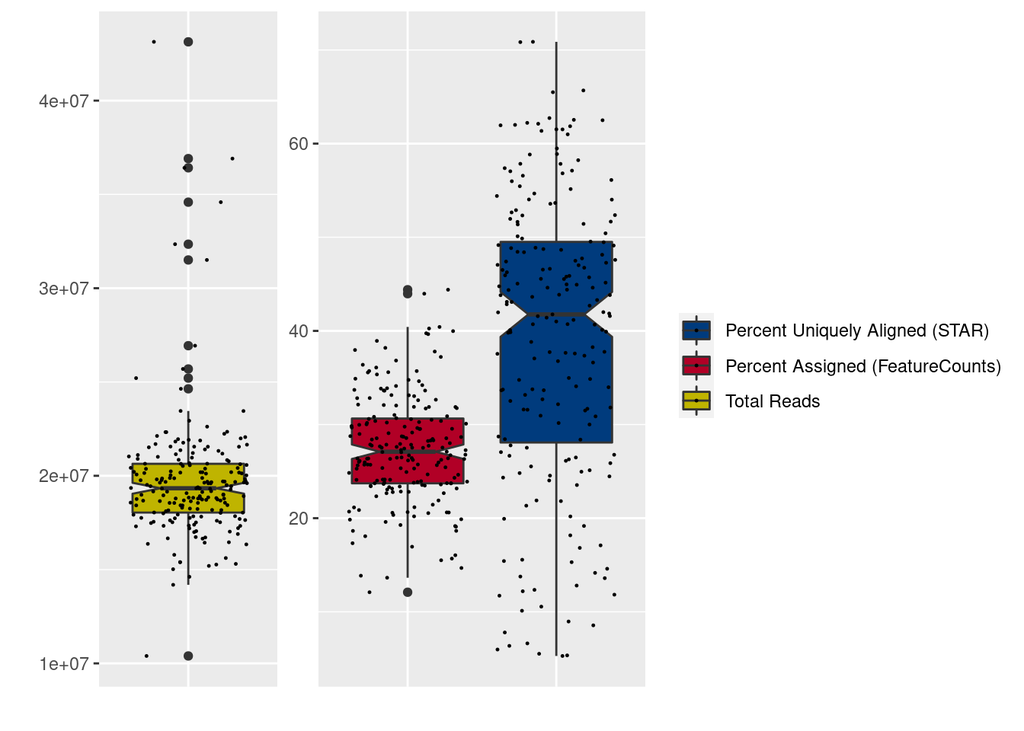

```r
aa_plot = ggplot(mqc_summary, aes(x = sequencing_metric, y = value, fill = sequencing_metric)) +
  geom_boxplot(notch = T) +
  scale_fill_manual(name = "",
                    limits = c("STAR_mqc_generalstats_star_uniquely_mapped_percent", "featureCounts_mqc_generalstats_featurecounts_percent_assigned", "total_sequences"),
                    labels = c("Percent Uniquely Aligned (STAR)", "Percent Assigned (FeatureCounts)", "Total Reads"),
                    values = c("#003B7D", "#B10026", "#BFB400")) +
  geom_point(position = "jitter", size = 0.2) +
  xlab("") +
  ylab("") +
  ggforce::facet_row(~ percent_col, scales = "free", space = "free") +
  theme(strip.background = element_blank(), strip.text.x = element_blank(),
        axis.ticks.x=element_blank(), axis.text.x=element_blank())
aa_plot
```

### ANOVA

```r
response = cbind(percent_mapped = mqc_summary$STAR_mqc_generalstats_star_uniquely_mapped_percent,
                   percent_assigned = md$featureCounts_mqc_generalstats_featurecounts_percent_assigned)
fit = manova(cbind(md$STAR_mqc_generalstats_star_uniquely_mapped_percent,
                   md$featureCounts_mqc_generalstats_featurecounts_percent_assigned) ~
               RIN + batch + Operator_RNA,
             data = md)
summary.aov(fit)
```

```
##  Response 1 :
##               Df  Sum Sq Mean Sq F value    Pr(>F)
## RIN            1  3731.8  3731.8  56.453 3.244e-13 ***
## batch          8 16183.1  2022.9  30.602 < 2.2e-16 ***
## Operator_RNA   2  2534.1  1267.0  19.167 1.044e-08 ***
## Residuals    440 29085.9    66.1
## ---
## Signif. codes:  0 '***' 0.001 '**' 0.01 '*' 0.05 '.' 0.1 ' ' 1
##
##  Response 2 :
##               Df Sum Sq Mean Sq F value    Pr(>F)
## RIN            1   15.4   15.39  0.8224     0.365
## batch          8 7893.0  986.63 52.7296 < 2.2e-16 ***
## Operator_RNA   2 1380.8  690.39 36.8975 1.534e-15 ***
## Residuals    440 8232.9   18.71
## ---
## Signif. codes:  0 '***' 0.001 '**' 0.01 '*' 0.05 '.' 0.1 ' ' 1
##
## 400 observations deleted due to missingness
```

Hard to differentiate batch and operator, but I had a feeling this would be the case. My numbers are clearly lower. Very interesting that RIN contributes only to mapping, not assignment.

## Effect of number of sorted cells

### ANOVA

```r
fit = manova(cbind(md$RIN,
                   md$RNA_concentration_pg_ul) ~
               num_sort_macroph,
             data = md)
summary.aov(fit)
```

```
##  Response 1 :
##                   Df Sum Sq Mean Sq F value  Pr(>F)
## num_sort_macroph   1   6.18  6.1758  3.3411 0.06824 .
## Residuals        442 817.01  1.8484
## ---
## Signif. codes:  0 '***' 0.001 '**' 0.01 '*' 0.05 '.' 0.1 ' ' 1
##
##  Response 2 :
##                   Df     Sum Sq    Mean Sq F value    Pr(>F)
## num_sort_macroph   1 3.9265e+10 3.9265e+10  286.28 < 2.2e-16 ***
## Residuals        442 6.0623e+10 1.3716e+08
## ---
## Signif. codes:  0 '***' 0.001 '**' 0.01 '*' 0.05 '.' 0.1 ' ' 1
##
## 408 observations deleted due to missingness
```

### Plotting

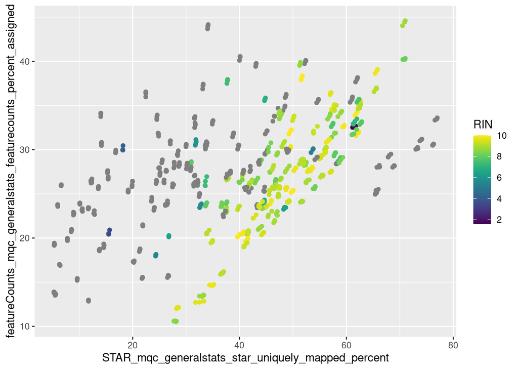

```r
ggplot(md, aes(x = STAR_mqc_generalstats_star_uniquely_mapped_percent,
               y = featureCounts_mqc_generalstats_featurecounts_percent_assigned,
               color = RIN)) +
  geom_point() +
  scale_color_viridis()
```

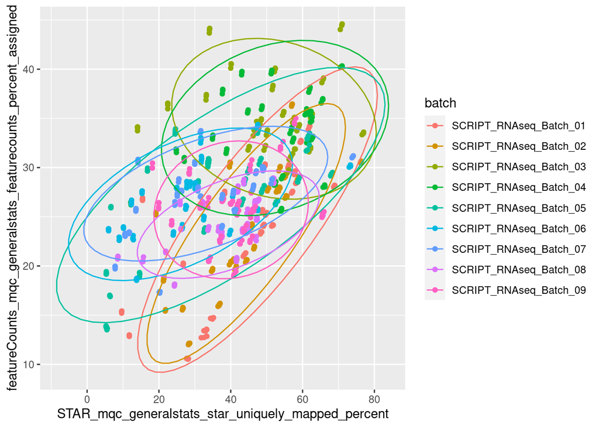

```r
ggplot(md, aes(x = STAR_mqc_generalstats_star_uniquely_mapped_percent,
               y = featureCounts_mqc_generalstats_featurecounts_percent_assigned,
               color = batch)) +
  geom_point() +
  stat_ellipse()
```

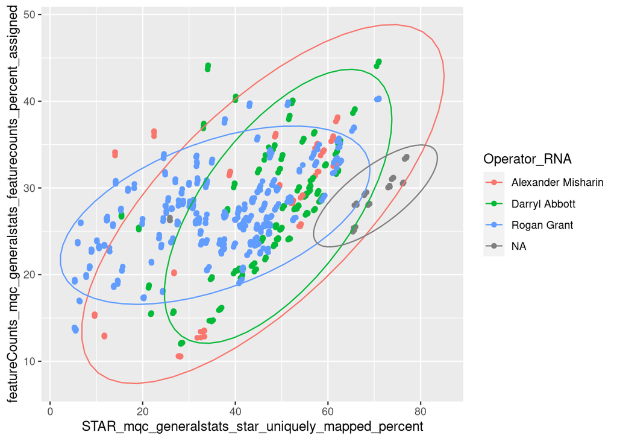

```r
ggplot(md, aes(x = STAR_mqc_generalstats_star_uniquely_mapped_percent,
               y = featureCounts_mqc_generalstats_featurecounts_percent_assigned,
               color = Operator_RNA)) +
  geom_point() +
  stat_ellipse()
```

Seems to be pretty variable between batch, with perhaps some influence from operator. I amy be better off preparing fewer plates at a time in the future (4-6 were prepared together). There are a lot of “hidden” variables in each batch, however. Batches 5-7 seem to be of the lowest quality, whereas 3 and 4 are the best by far.

## hURNA Correspondence

### Subset

```r
hURNA = script_bulk[, script_bulk$sample_type == "hURNA_control"]
hURNA = collapseReplicates(hURNA, groupby = hURNA$sample_batch)
```

### Corplot

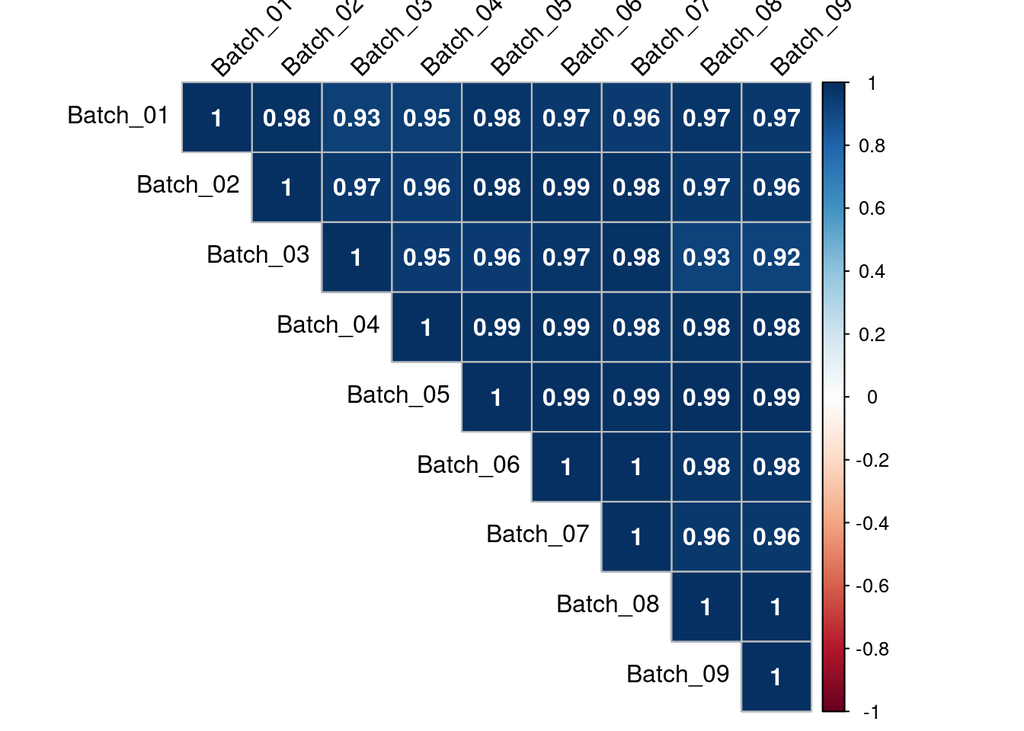

```r
hURNA_counts = counts(hURNA, normalized = F)
cors = cor(hURNA_counts)
colnames(cors) = substring(colnames(cors), 21)
rownames(cors) = substring(rownames(cors), 21)
corrplot(cors,
         method = "square",
         type = "upper",
         tl.col="black",
         addCoef.col = "white",
         tl.srt=45)
```

As expected, very high correspondence.

### PCA

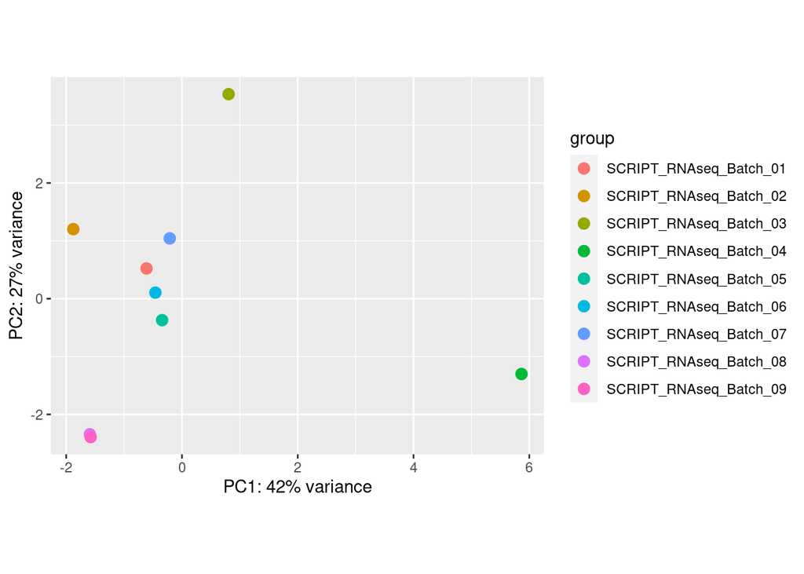

```r
plotPCA(vst(hURNA), intgroup = "batch")
```

Based on the correlations, it’s fair to say these differences are probably quite minor.

## Identify bad lanes

### PCA

With hURNA

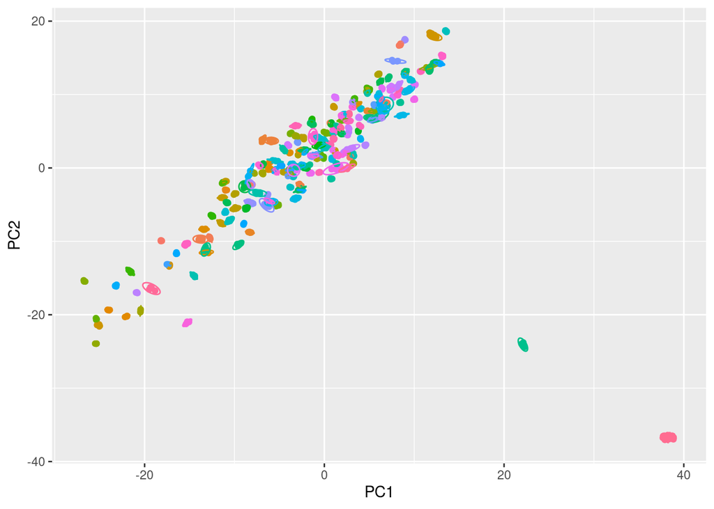

```r
d = plotPCA(vst(script_bulk),
        intgroup = c("sample_batch"),
        returnData = T)
ggplot(d, aes(x = PC1, y = PC2, color = sample_batch)) +
   geom_point() +
   stat_ellipse(aes(x = PC1, y = PC2, color = sample_batch), inherit.aes = F) +
  theme(legend.position = "none")
```

Without

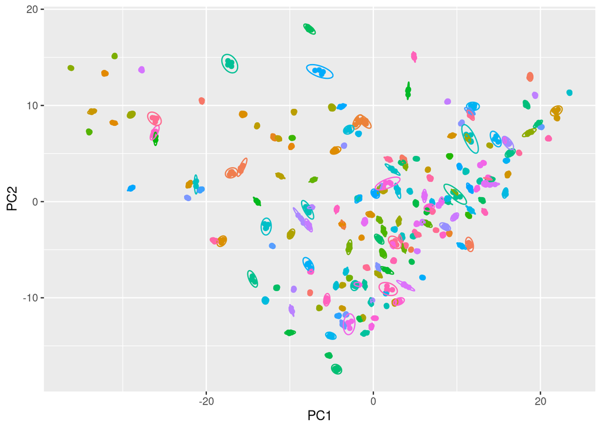

```r
d = plotPCA(vst(script_bulk_samples),
        intgroup = c("sample_batch"),
        returnData = T)
ggplot(d, aes(x = PC1, y = PC2, color = sample_batch)) +
   geom_point() +
   stat_ellipse(aes(x = PC1, y = PC2, color = sample_batch), inherit.aes = F) +
  theme(legend.position = "none")
```

We should be good on all samples - clusters are pretty tight, with no dramatic outliers.

### Collapse lanes

```r
script_bulk = collapseReplicates(script_bulk,
                                 groupby = script_bulk$sample_batch)
script_bulk_samples = collapseReplicates(script_bulk_samples,
                                 groupby = script_bulk_samples$sample_batch)
```

## Determine what to do with repeats

### Add repeat flag

```r
script_bulk$is_repeat = duplicated(script_bulk$sample) & script_bulk$sample_type == "sample"
script_bulk_samples$is_repeat = duplicated(script_bulk_samples$sample)
repeated_samples = script_bulk$sample[script_bulk$is_repeat]
```

### PCA

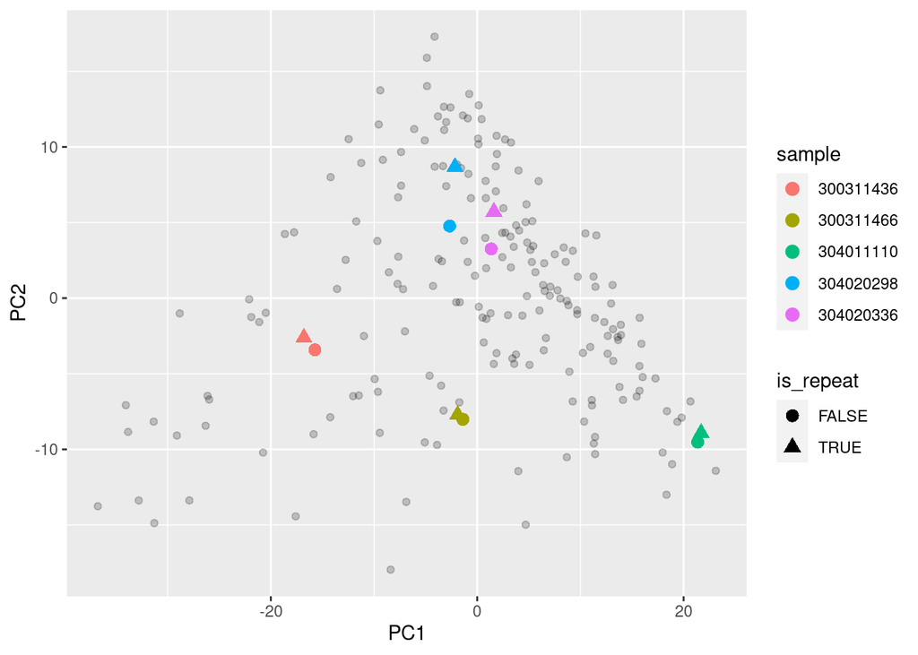

```r
d = plotPCA(vst(script_bulk_samples),
        intgroup = c("sample_batch", "sample", "is_repeat"),
        returnData = T)
d$highlight = d$sample %in% repeated_samples
ggplot(NULL) +
  geom_point(data = d, aes(x = PC1, y = PC2), alpha = 0.2) +
  geom_point(data = subset(d, highlight), aes(x = PC1, y = PC2, color = sample, shape = is_repeat), alpha = 1, size = 3)
```

Personally I vote to include both technical replicates and just collapse them. Given the clear similarity, any difference should be due to non-biological noise. We can always undo this later, but for now I will join them.

### Join as technical replicates

```r
script_bulk$safe_sample = ifelse(grepl("hURNA", script_bulk$sample),
                                 yes = paste(script_bulk$sample, script_bulk$batch, sep = "_"),
                                 no = script_bulk$sample)
script_bulk = collapseReplicates(script_bulk,
                                 groupby = script_bulk$safe_sample)
script_bulk_samples = collapseReplicates(script_bulk_samples,
                                 groupby = script_bulk_samples$sample)
```

## Batch effects

### PCA

With hURNA

[output not shown]

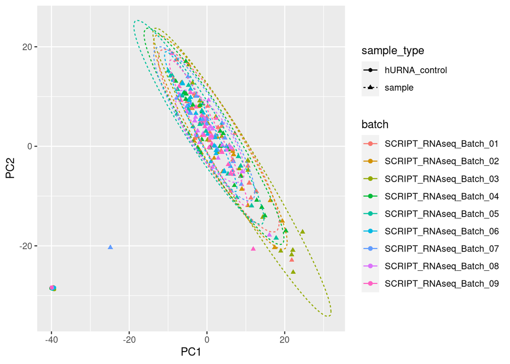

```r
d = plotPCA(vst(script_bulk),
        intgroup = c("batch", "sample_type"),
        returnData = T)
ggplot(d, aes(x = PC1, y = PC2, color = batch, shape = sample_type)) +
   geom_point() +
   stat_ellipse(aes(x = PC1, y = PC2, color = batch, linetype = sample_type), inherit.aes = F)
```

Outlier is 340228404. My comments on RNA trace: “Substantial degradation; serial sample. RAG”. Extremely poor alignment. Discard.

```r
script_bulk = script_bulk[, script_bulk$sample != "340228404"]
script_bulk_samples = script_bulk_samples[, script_bulk_samples$sample != "340228404"]
```

With hURNA after cleaning

[output not shown]

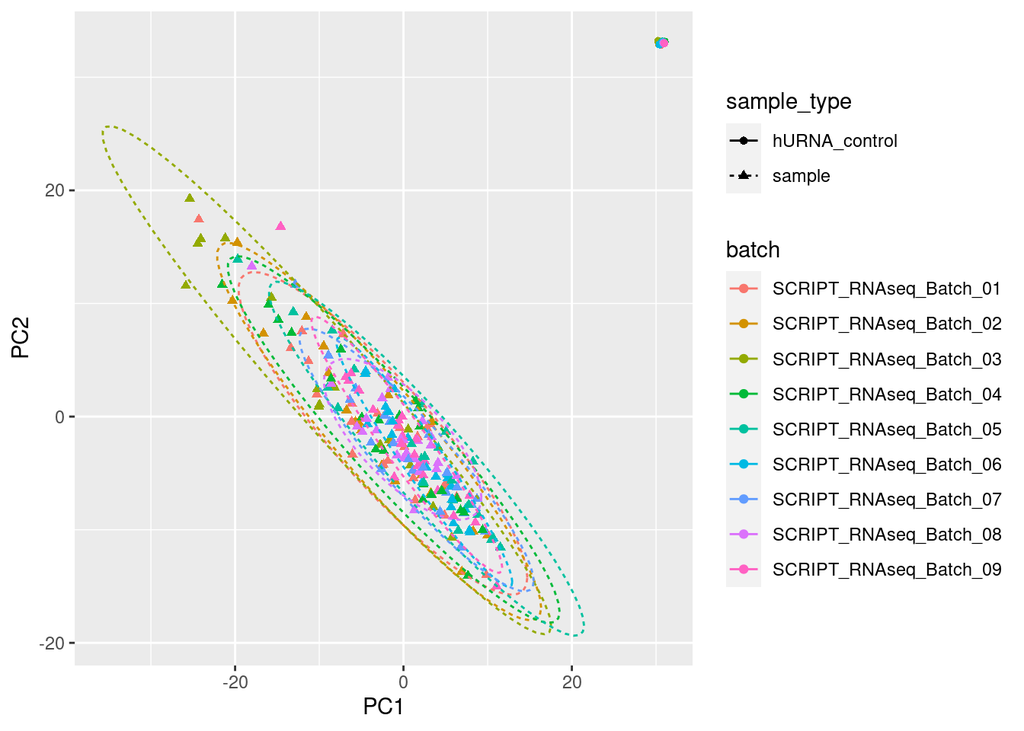

```r
d = plotPCA(vst(script_bulk),
        intgroup = c("batch", "sample_type"),
        returnData = T)
ggplot(d, aes(x = PC1, y = PC2, color = batch, shape = sample_type)) +
   geom_point() +
   stat_ellipse(aes(x = PC1, y = PC2, color = batch, linetype = sample_type), inherit.aes = F)
```

Without

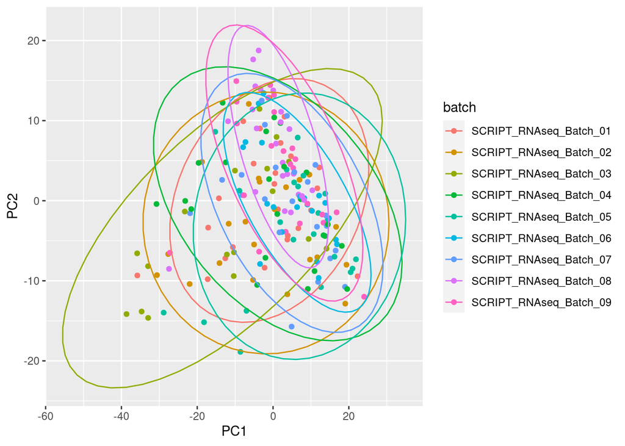

```r
d = plotPCA(vst(script_bulk_samples),
        intgroup = c("batch"),
        returnData = T)
ggplot(d, aes(x = PC1, y = PC2, color = batch)) +
   geom_point() +
   stat_ellipse(aes(x = PC1, y = PC2, color = batch), inherit.aes = F)
```

Looks pretty great overall. I think we can probably rule out major batch effect, but it may still be worth comparing the two models.

# Initial analysis

## What are the key differentiating genes?

```r
pca_data = plotPCA_manual(vst(script_bulk_samples),
        intgroup = c("batch"))
loadings = as.data.frame(pca_data$pca$rotation)
loadings = loadings %>%
  rownames_to_column(var = "ensembl_gene_id") %>%
  left_join(., ensembl_conv)
loadings$id = ifelse(is.na(loadings$external_gene_name),
                     yes = loadings$ensembl_gene_id,
                     no = loadings$external_gene_name)
loadings = loadings %>%
  column_to_rownames(var = "id") %>%
  dplyr::select(PC1:PC10)
```

PC1 is driven positively by lipid metabolism genes, such as FABP1, many of which are AM markers. Negative loadings may suggest MoAM presence: SPP1 is a major hit. More interesting though: it’s driven most strongly in that direction by Il8 and Il1b https://iai.asm.org/content/80/3/1140.short. PC2 is honestly not that different, but seems to have some proliferation character in the negative direction, homeotstatic MP function in the positive (MERTK, STAB1). Also some inflammatory character: F13A1, CCL2.

# Export for high-level analysis

```r
saveRDS(script_bulk, "/projects/b1038/Pulmonary/rgrant/script_bulk/Analysis/200618_script_bulk_des.rds")
saveRDS(script_bulk_samples, "/projects/b1038/Pulmonary/rgrant/script_bulk/Analysis/200618_script_bulk_des_no_hURNA.rds")
```

# Conclusions

1. Although there is some variability in sequencing quality, mapped and assigned reads lead to a very clean dataset with good between-batch correspondence.
2. Separation on PCA appears to be driven by real biological phenomena, based on enrichment of macrophage genes in the key PC loadings. Separation may be by AM subtype, expansion, and inflammation.